# Project.Final

### Multiple regression

Regression Model: $Y_i$ = $\beta_0$ + $\beta_1x_i$ + … + $\beta_{p-1}x_{i,p-1}$ + $\epsilon_i$ = $X'_i\beta$ + $\epsilon_i$ where $\epsilon_i$ ~ $N(0,\sigma^2)$

Best Fit line: $f(x)$ = $\hat{\beta_0}$ + $\hat{\beta_1}x$

```
##
## Call:
## lm(formula = log(M_avg) ~ log(flux) + dep, data = Data.noNA)
##
## Residuals:
##      Min       1Q   Median       3Q      Max
## -0.80880 -0.25965 -0.04166  0.19793  2.06123
##
## Coefficients:
##              Estimate Std. Error t value Pr(>|t|)
## (Intercept) 1.9800659  0.1342694  14.747   <2e-16 ***
## log(flux)   0.8496022  0.0303383  28.004   <2e-16 ***
## dep         0.0006387  0.0003763   1.698   0.0906 .
## ---
## Signif. codes:  0 '***' 0.001 '**' 0.01 '*' 0.05 '.' 0.1 ' ' 1
##
## Residual standard error: 0.3752 on 302 degrees of freedom
## Multiple R-squared:  0.7458, Adjusted R-squared:  0.7441
## F-statistic: 442.9 on 2 and 302 DF,  p-value: < 2.2e-16
```

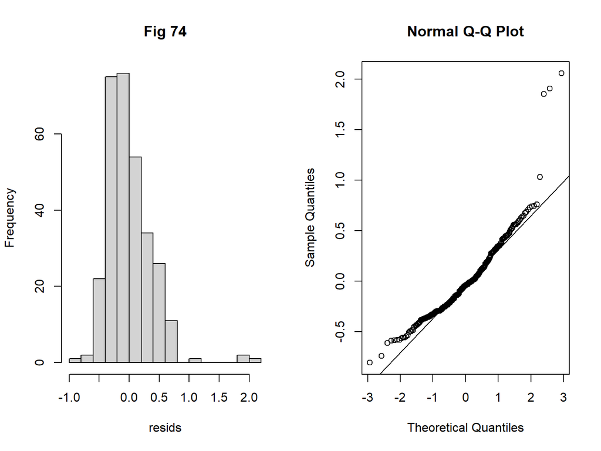

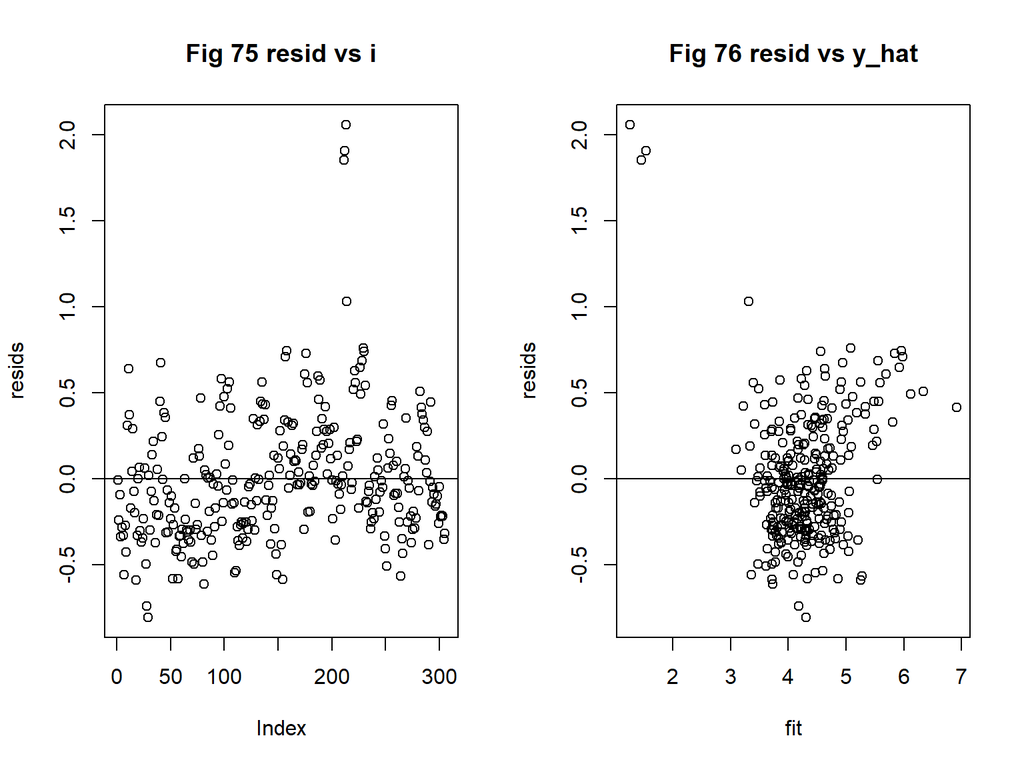

*Fairly normal and linear, but very clustered for residules*

which one is better?

|  | Res.Df | RSS | Df | Sum of Sq | F | Pr(>F) |
| --- | --- | --- | --- | --- | --- | --- |
| 1 | 303 | 42.91741 | NA | NA | NA | NA |
| 2 | 302 | 42.51172 | 1 | 0.4056958 | 2.882032 | 0.09060306 |

*There is no significance difference in the first anova model, our p-value is to large to assume that lossing df due to an extra parameter is worthwhile*

|  | Res.Df | RSS | Df | Sum of Sq | F | Pr(>F) |
| --- | --- | --- | --- | --- | --- | --- |
| 1 | 303 | 152.90688 | NA | NA | NA | NA |
| 2 | 302 | 42.51172 | 1 | 110.3952 | 784.2388 | 6.138939e-86 |

*However there our p-value is small in our second anova model indicates that losing df due to an extra paramter is worthwhile, or signiicantly improves the fit*

### ANCOVA

```
##       dep            M_avg             C_avg            N_avg
##  Min.   :150.0   Min.   :  16.49   Min.   :  0.41   Min.   : 0.070
##  1st Qu.:150.0   1st Qu.:  45.57   1st Qu.: 10.07   1st Qu.: 1.600
##  Median :200.0   Median :  64.90   Median : 15.09   Median : 2.510
##  Mean   :214.9   Mean   : 107.31   Mean   : 21.67   Mean   : 3.464
##  3rd Qu.:300.0   3rd Qu.: 101.87   3rd Qu.: 23.15   3rd Qu.: 4.100
##  Max.   :300.0   Max.   :1527.97   Max.   :310.63   Max.   :23.260
##      P_avg
##  Min.   :0.000300
##  1st Qu.:0.001900
##  Median :0.003500
##  Mean   :0.006229
##  3rd Qu.:0.006600
##  Max.   :0.148900
```

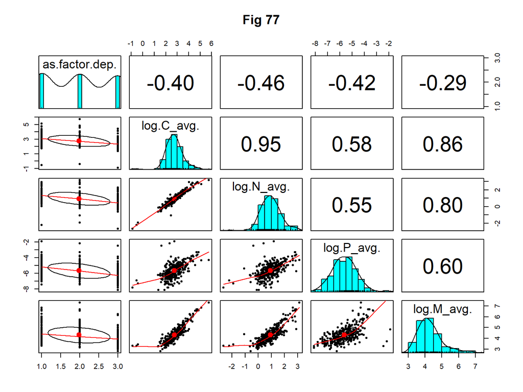

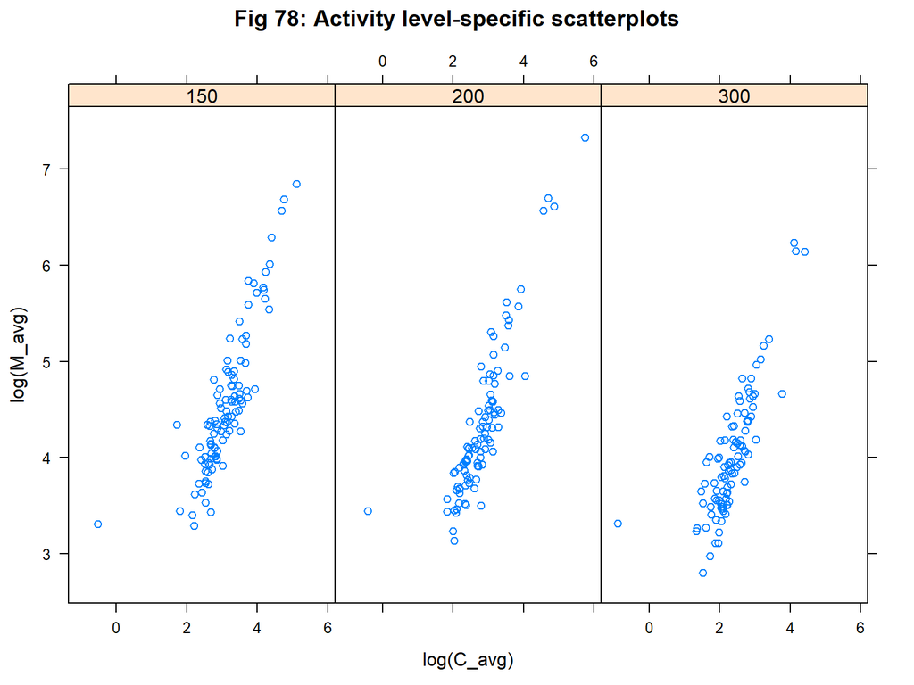

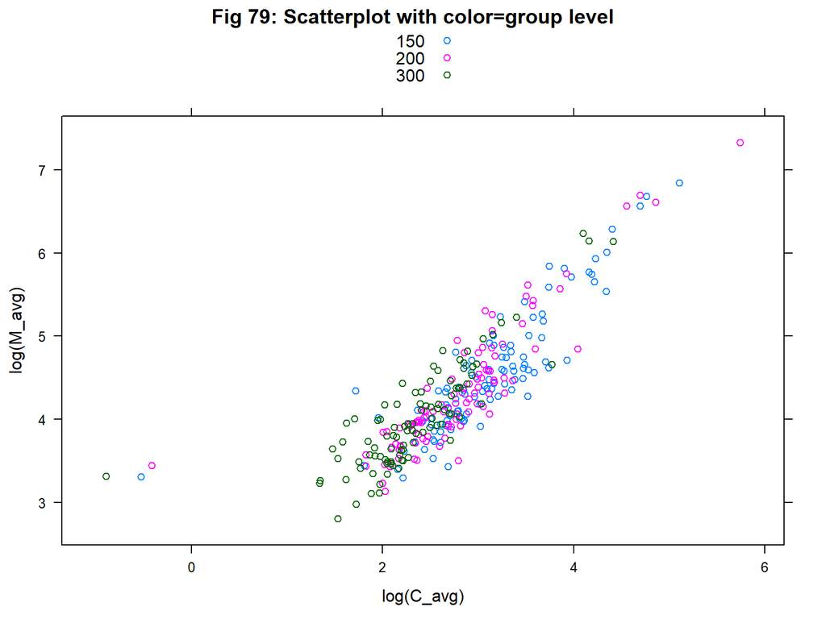

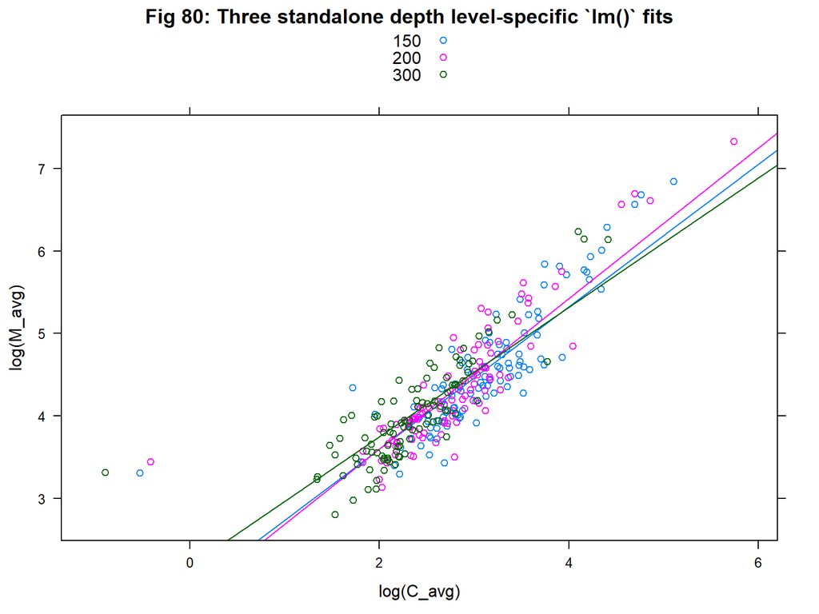

*After log transforming data, C, N, P, and M distributions look much more noraml. Linearlity is looking better, especially for C and N. Activity level specific scatterplots highlight the interaction with C and M through depths and have somewhat of a linear reationship*

```
##
## Call:
## lm(formula = log(M_avg) ~ log(C_avg) + log(N_avg) + log(P_avg) +
##     dep + as.factor(Year) + as.factor(month), data = ANOCOVA.data)
##
## Residuals:
##      Min       1Q   Median       3Q      Max
## -0.79080 -0.13761 -0.01913  0.13800  1.43640
##
## Coefficients:
##                       Estimate Std. Error t value Pr(>|t|)
## (Intercept)          3.1133046  0.3096395  10.055  < 2e-16 ***
## log(C_avg)           0.7104828  0.0953704   7.450 1.18e-12 ***
## log(N_avg)          -0.0154473  0.0893634  -0.173 0.862888
## log(P_avg)           0.1342152  0.0280565   4.784 2.79e-06 ***
## dep                  0.0008642  0.0003428   2.521 0.012248 *
## as.factor(Year)2006  0.0308480  0.1219263   0.253 0.800451
## as.factor(Year)2007 -0.0660690  0.1188095  -0.556 0.578594
## as.factor(Year)2008  0.0231154  0.1239489   0.186 0.852195
## as.factor(Year)2009  0.0406626  0.1181832   0.344 0.731057
## as.factor(Year)2010  0.0780500  0.1244893   0.627 0.531197
## as.factor(Year)2011  0.2954345  0.1219114   2.423 0.016014 *
## as.factor(Year)2012  0.4328774  0.1200874   3.605 0.000370 ***
## as.factor(Year)2013  0.1907860  0.1180029   1.617 0.107053
## as.factor(Year)2014  0.1115483  0.1224068   0.911 0.362928
## as.factor(Year)2015  0.2994775  0.1207850   2.479 0.013750 *
## as.factor(month)Aug -0.5090202  0.0904291  -5.629 4.41e-08 ***
## as.factor(month)Dec -0.4301884  0.0830806  -5.178 4.30e-07 ***
## as.factor(month)Feb -0.0916026  0.0795033  -1.152 0.250231
## as.factor(month)Jan -0.4878071  0.1898550  -2.569 0.010708 *
## as.factor(month)Jul -0.4706758  0.0759314  -6.199 2.04e-09 ***
## as.factor(month)Jun -0.4504058  0.0921921  -4.886 1.74e-06 ***
## as.factor(month)Mar  0.0141537  0.0983848   0.144 0.885715
## as.factor(month)May -0.4274599  0.0834863  -5.120 5.70e-07 ***
## as.factor(month)Nov -0.2829892  0.0891804  -3.173 0.001676 **
## as.factor(month)Oct -0.3367639  0.0923424  -3.647 0.000317 ***
## as.factor(month)Sep -0.3769393  0.0804426  -4.686 4.36e-06 ***
## ---
## Signif. codes:  0 '***' 0.001 '**' 0.01 '*' 0.05 '.' 0.1 ' ' 1
##
## Residual standard error: 0.2917 on 279 degrees of freedom
## Multiple R-squared:  0.858,  Adjusted R-squared:  0.8453
## F-statistic: 67.46 on 25 and 279 DF,  p-value: < 2.2e-16
```

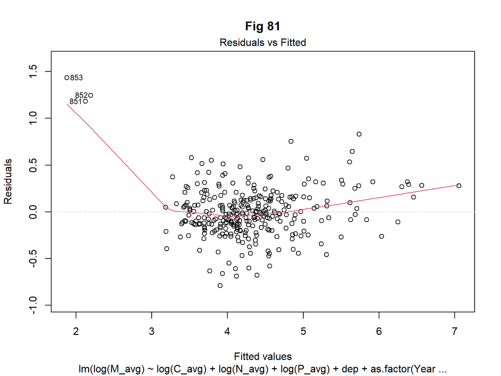

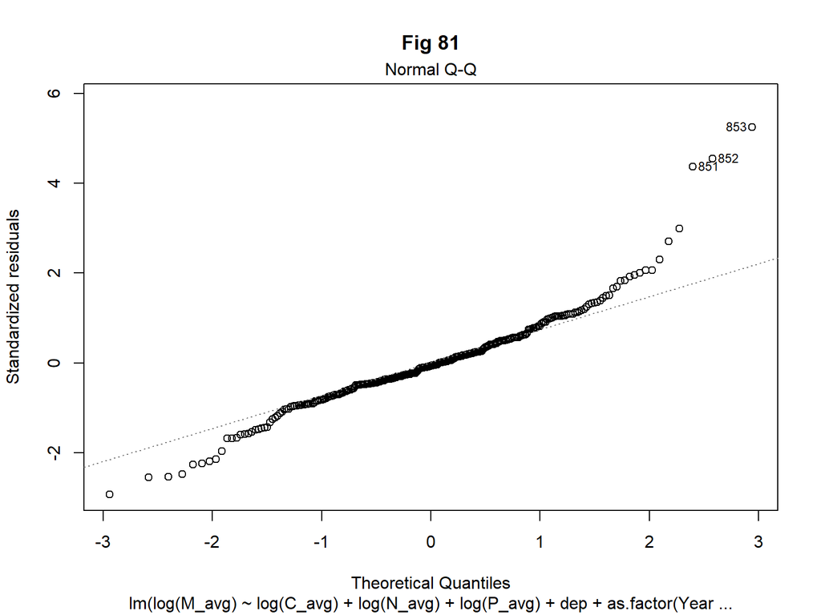

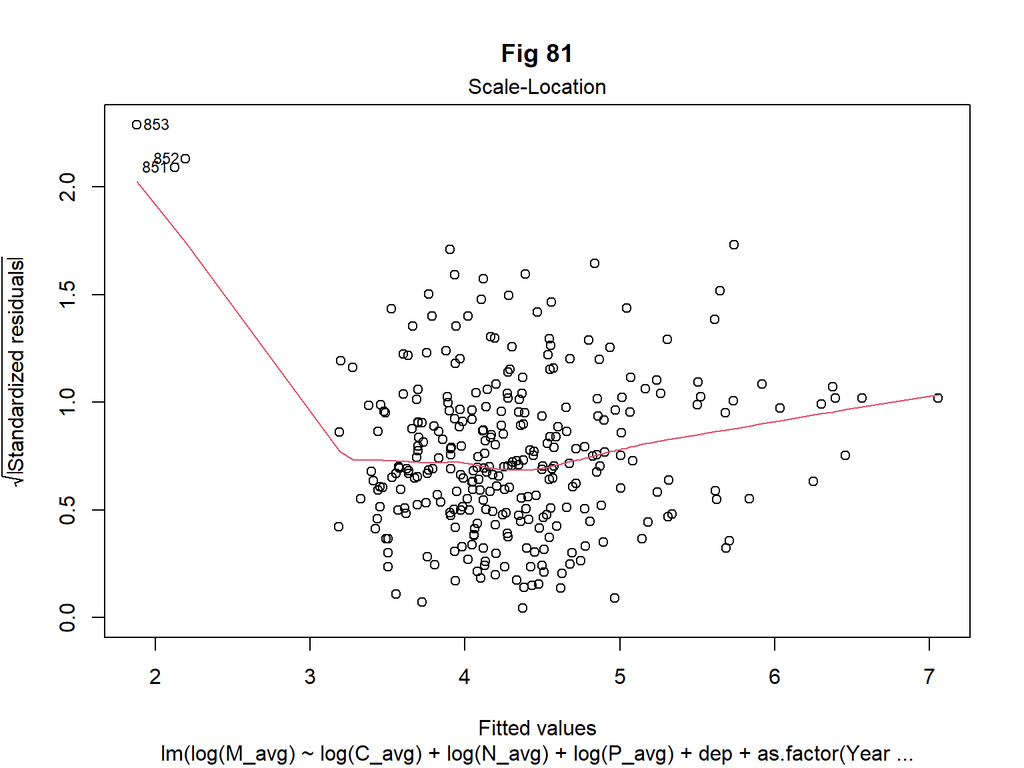

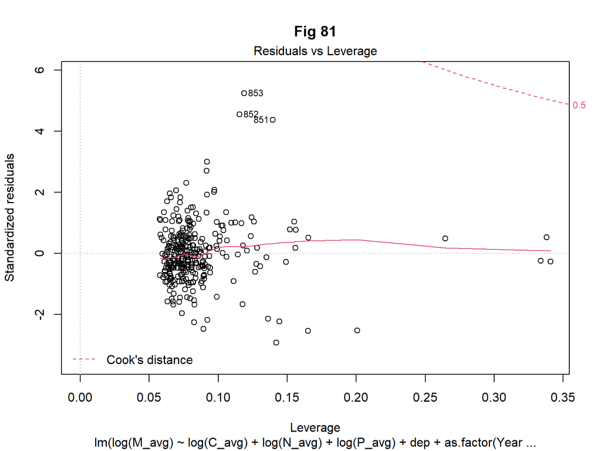

*These do not present strong relationships*